# ggplot2 - theme

##### **5.3.3 scale_x_continuous와 차이점**

ggplot2에서 축을 설정하는 함수는 scale_x_continuous, xlim 등 여러가지가 있습니다.  
그러나 이들과 coord_cartesian 사이에는 차이점이 있습니다. 우선 coord_cartesian은 데카르트 좌표계를 설정합니다.  
그래서 coord_cartesian함수를 사용하여 x와 y값을 지정하면 단순히 출력되는 좌표계의 범위를 지정하는 것을 의미합니다.  
일종의 좌표평면 확대로 생각하면 이해하기 쉽습니다. 그러나 scale_x_continuous에서 limit으로 수정하거나 xlim을 사용하면 지정 범위 밖에 있는 데이터를 관측에서 제외합니다.  
이해를 돕기 위해 히스토그램 그래프로 예시를 들겠습니다. 두 그래프 다 x축의 범위를 60에서 80으로 설정하였습니다.

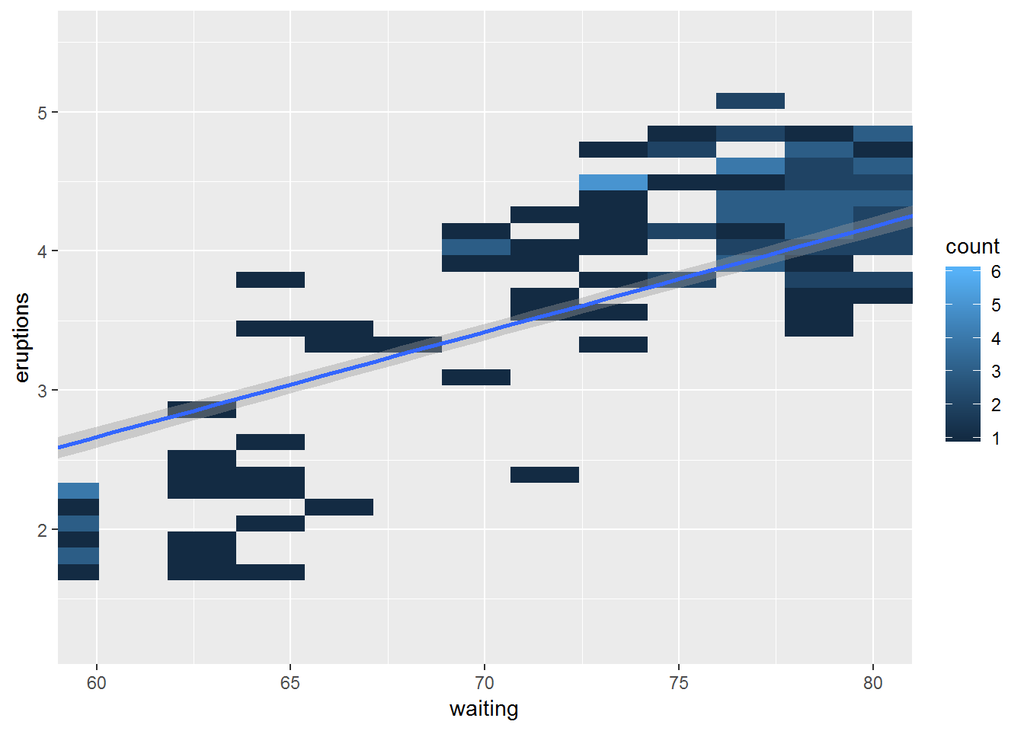

```r
library(ggplot2)

ggplot(faithful, aes(waiting, eruptions))+
  geom_bin2d()+
  coord_cartesian(xlim = c(60, 80))+
  geom_smooth(method = lm)
```

coord_cartesian함수를 사용하여 x축의 범위를 지정했습니다. 앞서 설명한 것처럼 단순히 좌표축을 확대한 것에 불가하기에 히스토그램의 모양 잡아 당긴 것처럼 변형되었습니다.  
그리고 faithful전체 데이터를 대상으로 하기 때문에 count의 최대값이 6으로 지정되어있습니다.

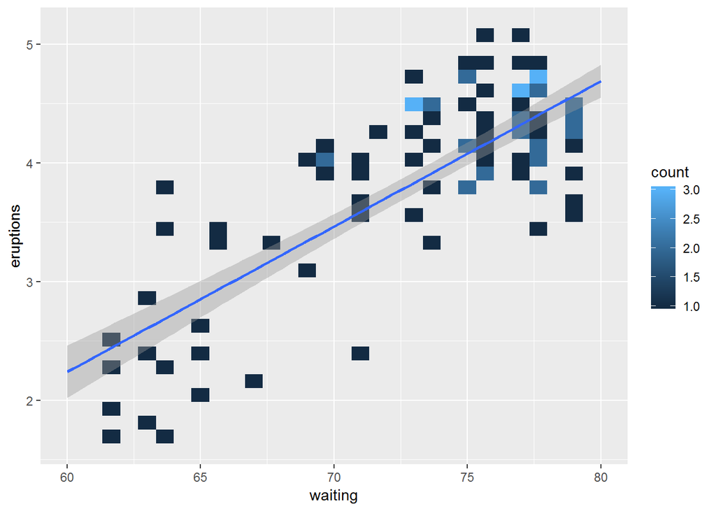

```r
library(ggplot2)

ggplot(faithful, aes(waiting, eruptions))+
  geom_bin2d()+
  scale_x_continuous(limits = c(60, 80))+
  geom_smooth(method = lm)
```

그러나 scale_x_continuous를 사용한 두 번째 그래프를 보면 확연한 차이를 보입니다.  
지정한 x축 범위를 초과하는 값은 계산에서 배제되어 히스토그램의 모양이 온전합니다.  
또한 범위에 속해있는 데이터만 분석하기 때문에 count의 최대값이 3에 머물러 있는 것을 알 수 있습니다.

단순히 그래프의 축을 확대하려면 coord_cartesian 함수를 사용하면 되지만, 그래프에 출력되는 데이터 자체를 수정하려면 scale_x_continuous 함수를 사용하면 됩니다.

#### **6. 패널(panel) 커스텀 하기**

##### **6.1 하나의 패널(One-panel)**

패널 커스텀 하기의 기본 데이터는 ggplot의 내장데이터인 Orange를 이용해 그린 나무의  
나이별 성장의 분포를 나타낸 그래프입니다. 이번에는 theme으로 panel의 디자인을 변경해보겠습니다.

```r
library(ggplot2)
```

```r
g1 <- ggplot(Orange, aes(age,circumference))+
       geom_point()+
       ggtitle('Orange')
```

빨간 색으로 표시된 영역을 panel이라 부릅니다. panel은 대표적으로 background와 grid의 디자인을 변경할 수 있습니다.

##### **6.1.1 Background**

background는 line이나 text가 아닌 사각형이므로 element_rect를 적용합니다. rect은 ‘사각형의’ 란 뜻을 가진 rectangular의 약자입니다.

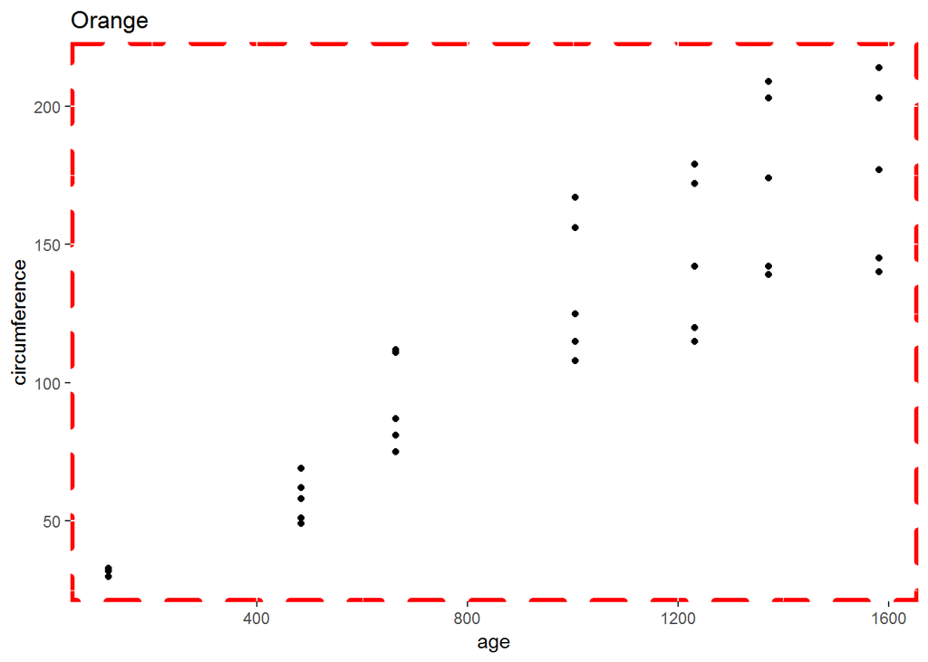

```r
g1 + theme(panel.background = element_rect(fill = 'white',
                                           colour = "red",
                                           linetype = 'dashed',
                                           size = 2))
```

##### **6.1.2 grid**

grid는 그래프를 구성하는 눈금을 의미합니다. grid는 major와 minor로 나뉩니다.

###### **(1) major**

grid.major는 x축과 y축의 값이 위치한 grid를 의미합니다. grid는 보시는 바와 같이 선의 형태이기 때문에 element_line을 적용합니다.

line에 적용할 수 있는 linetype, color, size 등 모든 값을 적용할 수 있습니다.

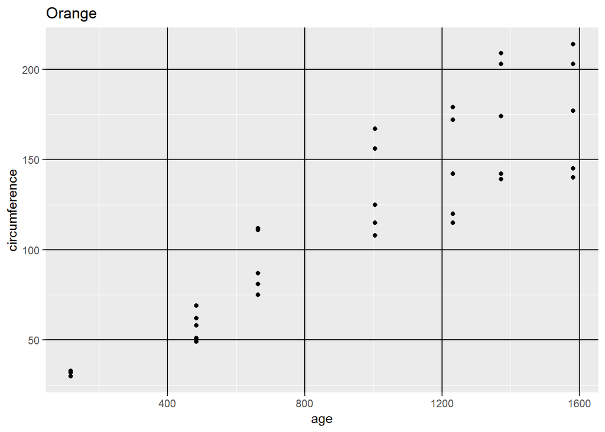

```r
g1 + theme(panel.grid.major = element_line(color = "black"))
```

###### **(2) minor**

grid.minor는 x, y 값에 위치하지 않은 눈금을 의미합니다.

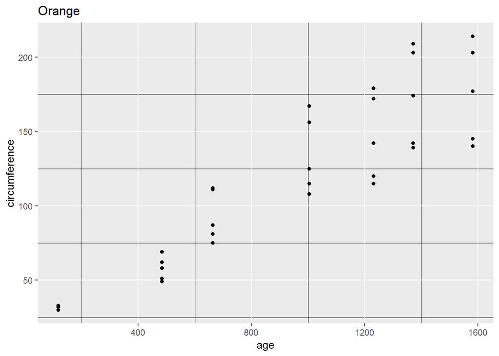

```r
g1 + theme(panel.grid.minor = element_line(colour = "black"))
```

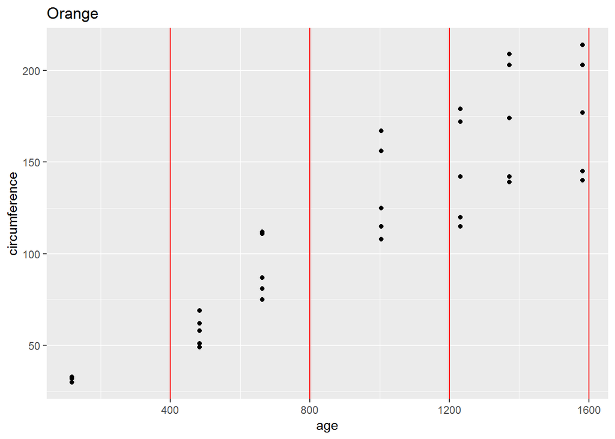

```r
g1 + theme(panel.grid.major.x = element_line(color='red'))
```

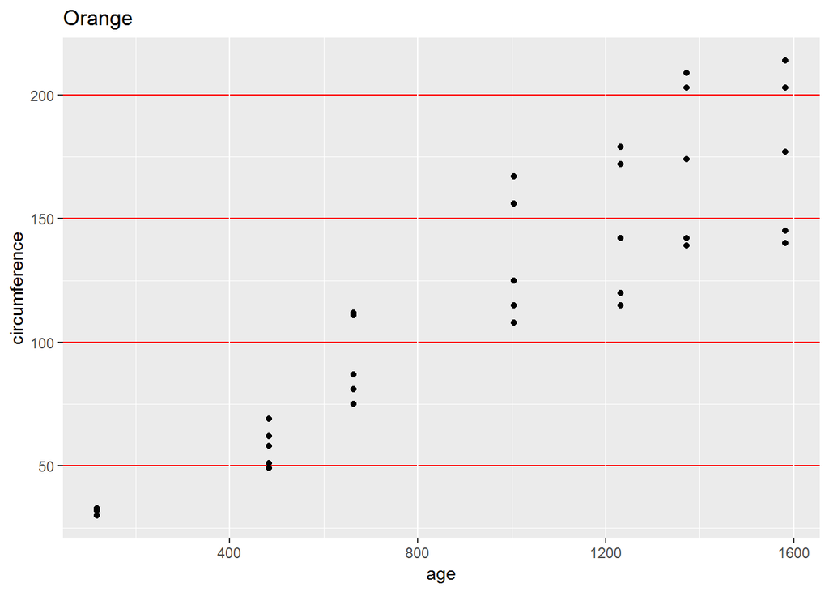

```r
g1 + theme(panel.grid.major.y = element_line(color='red'))
```

pannel.grid는 x축과 y축의 grid를 따로 설정해줄 수도 있습니다.

##### **6.1.3 blank**

blank는 ’빈, 공백의’을 의미하며, 공백을 적용할 때 사용합니다.

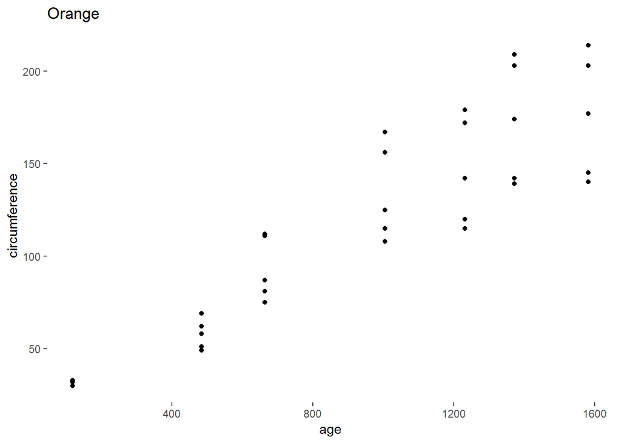

```r
g1 + theme(panel.background = element_blank())
```

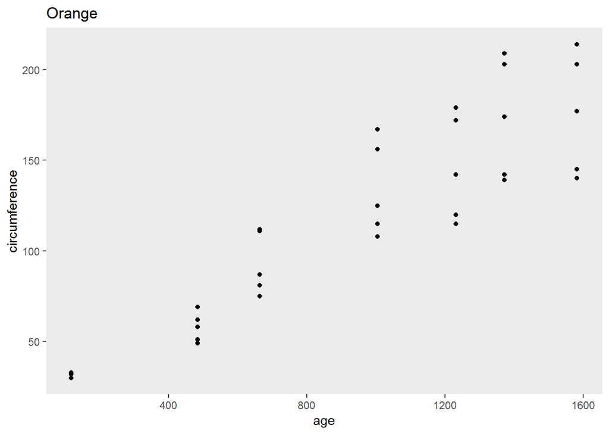

```r
g1 + theme(panel.grid = element_blank())
```

##### **6.2 두개의 패널 (Strip)**

strip은 한 plot내 둘 이상의 panel을 가진 그래프의 디자인을 변경할 때 활용합니다.

```r
d2 <- ggplot(iris, aes(Petal.Length, Petal.Width))+
       geom_point()+
        facet_wrap(~Species)
```

##### **6.2.1 Background**

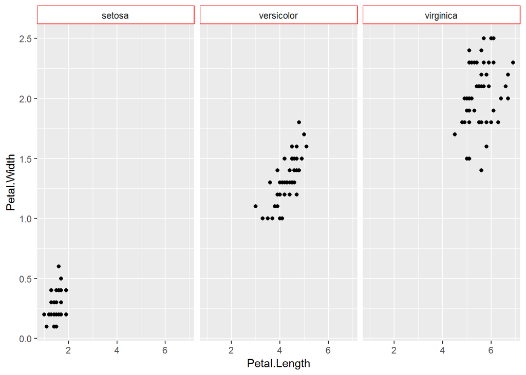

```r
d2 + theme(strip.background = element_rect(colour = "red",
                                           fill = "white"))
```

##### **6.2.2 text**

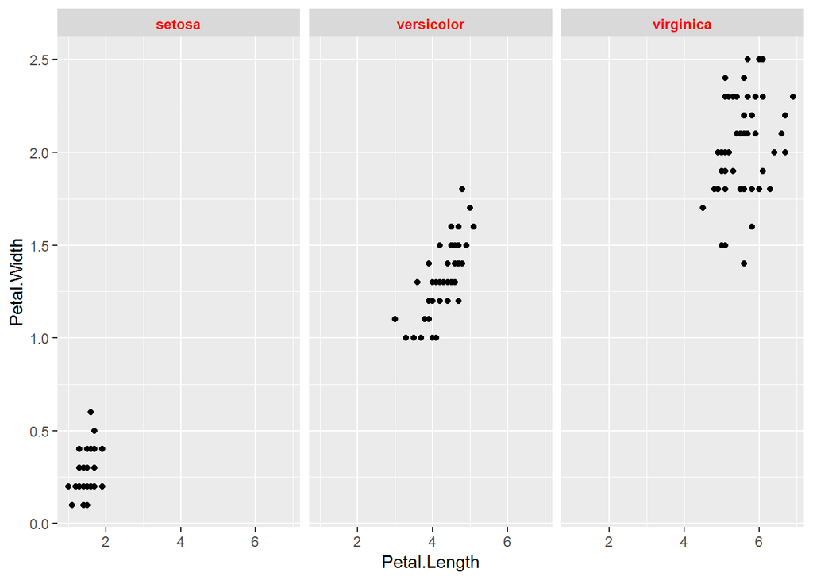

```r
d2 + theme(strip.text.x = element_text(colour = "red",
                                       face = "bold"))
```

##### **6.2.3 blank**

blank는 ’빈, 공백의’을 의미하며, 공백을 적용할 때 사용합니다.

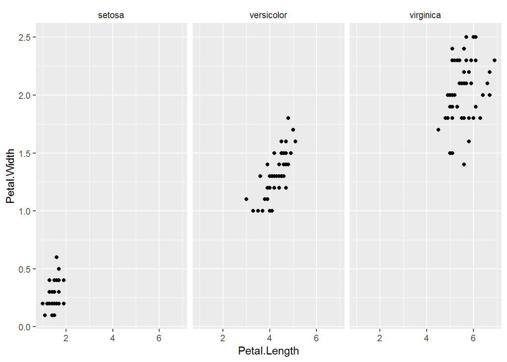

```r
d2 + theme(strip.background = element_blank())
```

theme의 다른 함수들과 함께 적용할 수 있습니다.

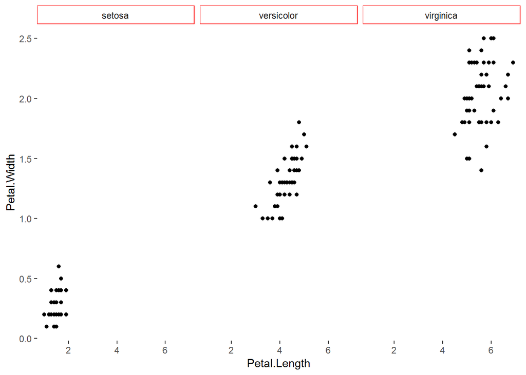

```r
d2 + theme(strip.background = element_rect(colour = "red",
                                           fill = "white"),
           panel.background= element_blank())
```

#### **[부록] them 함수의 elements 설명**

| Element | 설명 | 함수 구성요소 및 기본 설정 |
| --- | --- | --- |
| `element_blank` | 아무것도 그리지 않음 | element_blank |
| `element_rect` | 테두리와 배경 | fill 배경 채움 색상, color 색상, size 크기, linetype 선 종류, inherit.blank 상위 element의 blank 상속여부 |
| `element_line` | 선 | color 색상, size 크기, linetype 선 종류, lineend 선 끝 스타일, arrow 화살표 종류, inherit.blank 상위 element의 blank 상속여부 |
| `element_text` | 글자 | family 글자종류, face 글자모양, color, size, hjust 수평맞춤, vjust 수직 맞춤, angle 각도, lineheight 선 높이, margin 글자주위공간, debug 디버깅 여부, inherit.blank |

### **참고자료**

[ggplot2 그래프 커스텀 하기](http://blog.naver.com/PostView.nhn?blogId=nife0719&logNo=221000580841)

[R - ggplot2(coder1252님의 블로그)](https://m.blog.naver.com/coder1252/220931262683)